# Data Replication Assignment: Developmental stress and telomere dynamics in a genetically polymorphic species

### Introduction

In this article by Grunst, AS, Grunst, ML, Gonser, RA and Tuttle, EM (2019), they studied different factors that produce different patterns of senescence (the decline in physical and reproductive performance with age) in the dimorphic white-throated sparrow (Zonotrichia albicollis), that displays a genetically determined polymorphism in both sexes (tan or white). Apart from the different genetics, the white-throated sparrow morphs also exhibit different behaviours. They studied individual-level factors derived from developmental stress, focusing in telomere lenght and oxidative stress. They look at these variables are affected by growth rate, size rank, etc. taking into account the different morph-sex classes and individual identity. The objective of this was trying to see if morph–sex differences in OS or telomere length occur in the nestlings and if they can explain the different patterns of senescence during adulthood. Previous studies have mixed results about the relationship of telomere lenght and oxidative stress. The study was done in nestlings.

Telomere length was determined using a relative real-time qPCR assay, which measures telomere length relative to a single copy reference gene. They used glyceraldehyde-3-phosphate dehydrogenase (GAPDH) as our reference gene.

They measured total antioxidant capacity (TAC) in the plasma using the OXY-adsorbent kit, and reactive oxygen metabolites (ROMs) in the plasma using Diacron International’s d-ROMs kit. Oxidative stress was calculated as: mM ROMs/mM HOCl neutralized (TAC) × 1,000.

Growth rates were calculated using the slope of a linear regression of mass versus nestling age. Nestling size rank was determined by ordering nestlings within broods from largest to smallest. The largest nestling received a rank of 1 and the smallest a rank equal to the brood size.

### Statistical analysis

In order to do this study, they performed analysis by linear mixed effect models (LMM) to analyse differences in OS and RTL according to different factors, with nest, father and mother identity as random effects. As fixed effects, they entered nestling morph–sex, the morph composition of the parental pair, brood size, clutch initiation date, time of blood sampling (excluded in the telomere model), year, growth rate, size rank and age. OS level was additionally included as a fixed effect in the model predicting RTL.

#### Loading necessary packages

```r
library(lme4) ## For mixed effects models
library(curl) ## To load the data
```

```r
library(sciplot) ## To calculate the standard error
library(ggplot2) ## To make nice plots
library(gridExtra) ## To combine ggplots
## In the paper they state that they have used the package lme4 for this analysis.
```

#### Loading the data

Now we are going to load and take a look at our data

```r
f <- curl("https://raw.githubusercontent.com/dalarre/replication_dalarre/main/telomere_data_1_pruebas.csv")
d <- read.csv(f, header = TRUE, sep = ";", stringsAsFactors = FALSE)
head(d)
```

```
##   Count Plate Year PlateYear Position Sample.Name Sample.R.Name   FullBand
## 1     5     1 2014    2014-1      G10       72530         72530 2281-72530
## 2     6     1 2014    2014-1      H10       72530         72530 2281-72530
## 3     7     1 2014    2014-1      E11       72531         72531 2281-72531
## 4     8     1 2014    2014-1      F11       72531         72531 2281-72531
## 5     9     1 2014    2014-1       E4       72536         72536 2281-72536
## 6    10     1 2014    2014-1       F4       72536         72536 2281-72536
##   Colors Age MorphWT SexMF Type   BandDate NumDate  Time  NumTime   ClutchID
## 1   YFKO   L       T     F   TF 14/06/2014      45 12:09 12.15000  2014BIMC1
## 2   YFKO   L       T     F   TF 14/06/2014      45             NA  2014BIMC1
## 3   FOPG   L       T     M   TM 14/06/2014      45 12:50 12.83333  2014BIMC1
## 4   FOPG   L       T     M   TM 14/06/2014      45             NA  2014BIMC1
## 5   PRKF   L       T     F   TF 16/06/2014      47 10:06 10.10000 2014ASS1C1
## 6   PRKF   L       T     F   TF 16/06/2014      47             NA 2014ASS1C1
##   White.comps Tan.comps Male.comps Fem.comps WM.comps TM.comps WF.comps
```

[output cut: 55 more lines]

```r
names(d)
```

```
##  [1] "Count"             "Plate"             "Year"
##  [4] "PlateYear"         "Position"          "Sample.Name"
##  [7] "Sample.R.Name"     "FullBand"          "Colors"
## [10] "Age"               "MorphWT"           "SexMF"
## [13] "Type"              "BandDate"          "NumDate"
## [16] "Time"              "NumTime"           "ClutchID"
## [19] "White.comps"       "Tan.comps"         "Male.comps"
## [22] "Fem.comps"         "WM.comps"          "TM.comps"
## [25] "WF.comps"          "TF.comps"          "ClutchNum"
## [28] "PairType"          "NestlingAge"       "BroodSize"
## [31] "FatherBand"        "FatherColor"       "MotherBand"
## [34] "MotherColor"       "FatherTEL"         "MotherTEL"
## [37] "Mass"              "Left.Tarsus"       "Right.Tarsus"
## [40] "CqT"               "CqT.Mean"          "Cq.Error"
## [43] "ETCpT.C..CpT.S."   "ETCpT.C..CpT.S.2"  "CqR"
## [46] "CqR.Mean"          "CqR.Error"         "ERCpR.S..CpR.C."
## [49] "ERCpR.S..CpR.C..1" "RTL"               "CV.RTL"
## [52] "RTL.average"       "ClutchNum.1"       "Day"
## [55] "Size.Rank"         "Male.Morph"        "Growth.rate..g"
## [58] "Growth.rate.mm"    "Intercept.g"       "Intercept.mm"
## [61] "OXY"               "OXY.ave"           "CV.OXY"
## [64] "ROM"               "ROM.ave"           "CV.ROM"
## [67] "OS"
```

```r
summary(d)
```

```
##      Count           Plate            Year       PlateYear
##  Min.   :  5.0   Min.   :1.000   Min.   :2014   Length:443
##  1st Qu.:181.5   1st Qu.:1.000   1st Qu.:2014   Class :character
##  Median :334.0   Median :2.000   Median :2015   Mode  :character
##  Mean   :319.6   Mean   :2.442   Mean   :2015
##  3rd Qu.:460.5   3rd Qu.:3.000   3rd Qu.:2015
##  Max.   :597.0   Max.   :4.000   Max.   :2015
##                  NA's   :2
##    Position          Sample.Name    Sample.R.Name     FullBand
##  Length:443         Min.   :25801   Min.   :25801   Length:443
##  Class :character   1st Qu.:25897   1st Qu.:25897   Class :character
##  Mode  :character   Median :37962   Median :37962   Mode  :character
##                     Mean   :47082   Mean   :47082
##                     3rd Qu.:72542   3rd Qu.:72542
##                     Max.   :77797   Max.   :77797
##
##     Colors              Age              MorphWT             SexMF
##  Length:443         Length:443         Length:443         Length:443
##  Class :character   Class :character   Class :character   Class :character
##  Mode  :character   Mode  :character   Mode  :character   Mode  :character
##
##
##
##
##      Type             BandDate            NumDate           Time
##  Length:443         Length:443         Min.   : 38.00   Length:443
##  Class :character   Class :character   1st Qu.: 43.00   Class :character
##  Mode  :character   Mode  :character   Median : 52.00   Mode  :character
##                                        Mean   : 58.67
##                                        3rd Qu.: 73.00
##                                        Max.   :101.00
##
##     NumTime         ClutchID          White.comps      Tan.comps
##  Min.   : 6.117   Length:443         Min.   :0.000   Min.   :0.000
##  1st Qu.: 7.696   Class :character   1st Qu.:1.000   1st Qu.:1.000
##  Median : 9.833   Mode  :character   Median :1.000   Median :1.000
##  Mean   : 9.805                      Mean   :1.192   Mean   :1.452
##  3rd Qu.:11.738                      3rd Qu.:2.000   3rd Qu.:2.000
##  Max.   :14.350                      Max.   :3.000   Max.   :6.000
##  NA's   :227                         NA's   :339     NA's   :339
```

[output cut: 81 more lines]

```
##  Min.   : 94.13   Min.   :120.6   Min.   :0.00000   Min.   :0.004354
##  1st Qu.:232.09   1st Qu.:234.3   1st Qu.:0.04253   1st Qu.:0.699194
##  Median :281.15   Median :286.5   Median :0.10386   Median :0.961714
##  Mean   :286.39   Mean   :286.8   Mean   :0.11753   Mean   :1.067805
##  3rd Qu.:331.40   3rd Qu.:328.6   3rd Qu.:0.17017   3rd Qu.:1.350607
##  Max.   :552.25   Max.   :542.4   Max.   :0.52848   Max.   :3.338046
##  NA's   :12       NA's   :230     NA's   :232       NA's   :18
##     ROM.ave            CV.ROM              OS
##  Min.   :0.00435   Min.   :0.00000   Min.   : 0.01325
##  1st Qu.:0.70184   1st Qu.:0.04675   1st Qu.: 2.41598
##  Median :0.99667   Median :0.09697   Median : 3.44028
##  Mean   :1.06316   Mean   :0.13920   Mean   : 3.81558
##  3rd Qu.:1.28981   3rd Qu.:0.20266   3rd Qu.: 4.83242
##  Max.   :3.19856   Max.   :0.72831   Max.   :15.77315
##  NA's   :231       NA's   :234       NA's   :233
```

Here we can see a summary of our data. Notice how there are two replicates of each individual. We are going to focus in the OS variable, which already has the results of oxidative stress after calculating it with the formula described before. We are also going to use the RTL.average variable, which refers to the relative telomere lenght averaged from the two measures of the same individual. MorphWT and SexMF define the morph-sex of the individuals and are also essential variables for this study. Notice that they are defined as characters. They are combined in the variable type

Now we are going to calculate the mean and standard error of OS to see if it is the same as they say in the article:

```r
os <- na.omit(d$OS) ## omit the NAs
mean(os)
```

```
## [1] 3.815577
```

```r
se(os)
```

```
## [1] 0.1410798
```

```r
length(os)
```

```
## [1] 210
```

The mean and SE are similar but a bit different of what the article states (3.91 ± 0.13). The difference is probably due to a difference in the number of samples. In the article they say that N = 244, but in the data posted in dryad used here, N = 210.

Now we are going to do the same with the average relative telomere length:

```r
telomere <- na.omit(d$RTL.average) ## omit the NAs
mean(telomere)
```

```
## [1] 1.151681
```

```r
se(telomere)
```

```
## [1] 0.02848674
```

```r
length(telomere)
```

```
## [1] 217
```

The results are again slightly different because of the dataset differences. They results are 1.137 ± 0.028 with a sample size of 218.

### Replicating Figure 3:

The figure are two barplots and their height is the mean of oxidative stress or relative telomere length of each type of morph-sex. The first problem is how to divide the dataset into the different morph-sex types. I found you can do this with the split function:

```r
morphsex <- na.omit(d$Type) ## Need to omit the NAs to avoid errors
groups <- split(d, f = factor(morphsex)) ## This divides the dataset d into groups defined by the different categories in the type variable.
```

```r
TF_OSmean <- mean(na.omit(groups$TF$OS))
TF_OSse <- se(na.omit(groups$TF$OS))

TM_OSmean <- mean(na.omit(groups$TM$OS))
TM_OSse <- se(na.omit(groups$TM$OS))

WF_OSmean <- mean(na.omit(groups$WF$OS))
WF_OSse <- se(na.omit(groups$WF$OS))

WM_OSmean <- mean(na.omit(groups$WM$OS))
WM_OSse <- se(na.omit(groups$WM$OS))

morphsex_OSmeans <- c(TF_OSmean,TM_OSmean,WF_OSmean,WM_OSmean)
morphsex_OSse <- c(TF_OSse,TM_OSse,WF_OSse,WM_OSse)



TF_RTLmean <- mean(na.omit(groups$TF$RTL.average))
TF_RTLse <- se(na.omit(groups$TF$RTL.average))

TM_RTLmean <- mean(na.omit(groups$TM$RTL.average))
TM_RTLse <- se(na.omit(groups$TM$RTL.average))

WF_RTLmean <- mean(na.omit(groups$WF$RTL.average))
WF_RTLse <- se(na.omit(groups$WF$RTL.average))

WM_RTLmean <- mean(na.omit(groups$WM$RTL.average))
WM_RTLse <- se(na.omit(groups$WM$RTL.average))

morphsex_RTLmeans <- c(TF_RTLmean,TM_RTLmean,WF_RTLmean,WM_RTLmean)
morphsex_RTLse <- c(TF_RTLse,TM_RTLse,WF_RTLse,WM_RTLse)


df <- data.frame(type = c("TF", "TM", "WF", "WM"), OSmean = morphsex_OSmeans, OSse = morphsex_OSse, RTLmean = morphsex_RTLmeans, RTLse = morphsex_RTLse)

## Now I calculate the means and standard errors of the different morph-sex types for the variables we are going to represent in the barplot and create a dataframe to manipulate them easily.
```

Now that we have the data, lets do the graphs. For that, I use ggplot2 and the gridExtra to put the 2 ggplots together as in the original figure.

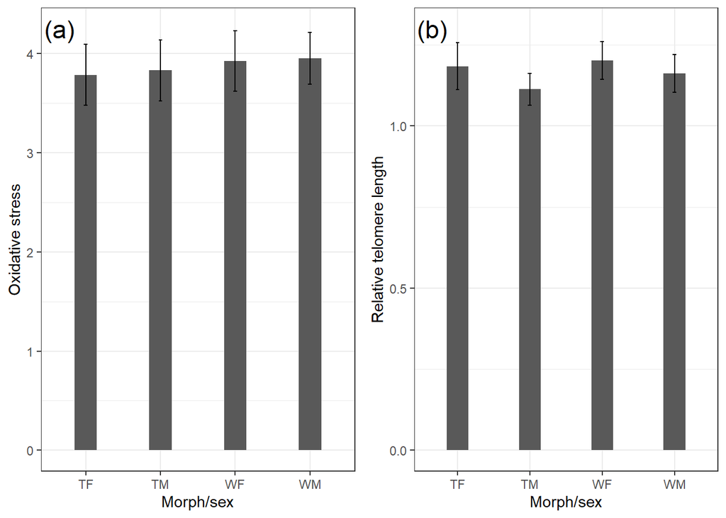

```r
p <- ggplot(data = df, aes(x=type, y=OSmean)) + geom_bar(stat="identity", width = 0.3) + geom_errorbar(aes(x=type, ymin = morphsex_OSmeans-morphsex_OSse, ymax = morphsex_OSmeans+morphsex_OSse), width = 0.05 ) + xlab("Morph/sex") + ylab("Oxidative stress") + annotate("text", x = 0.65, y = 4.25, label = "(a)", size = 6) + theme_bw()

## The heights are the means and the error bars are the standard errors as it is described in the figure

q <- ggplot(data = df, aes(x=type, y=RTLmean)) + geom_bar(stat="identity", width = 0.3) + geom_errorbar(aes(x=type, ymin = morphsex_RTLmeans-morphsex_RTLse, ymax = morphsex_RTLmeans+morphsex_RTLse), width = 0.05 ) + xlab("Morph/sex") + ylab("Relative telomere length") + annotate("text", x = 0.65, y = 1.3, label = "(b)", size = 6) + ylim(0, 1.3) + theme_bw()


grid.arrange(p, q, nrow = 1)
```

Let’s compare it now with the original figure:

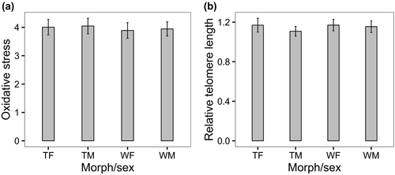

The barplots are similar but not exactly the same. I believe this is because some points they used were removed from the published dataset, as the sample sizes they metion aren’t the same as the ones in the dataset, so some data is missing.

### Replicating table 2

This analysis requires a mixed effects model. In this table, they predict RLT from OS and growth rate with year (2014 or 2015) as a fixed effect. Nest ID, Father ID and Mother ID are the random effects. The problem is I don’t know which of the variables in the dataset is the Nest ID or if it is even included in the dataset, so I’m going to ignore that random effect.

```r
growthrate <- d$Growth.rate..g/d$Growth.rate.mm ## Growth rate is calculated as g/mm
e <- cbind(d,growthrate) ## Create a new data frame with the calculated growth rate.


model1 <- lmer(data = e, RTL.average ~ OS + growthrate + Year + (1|FatherBand) + (1|MotherBand))

model2 <- lmer(data = e, RTL.average ~ OS + growthrate + Year + (1 + OS|FatherBand) + (1 + OS|MotherBand) + (1 + growthrate|FatherBand) + (1 + growthrate|MotherBand))
```

```
## boundary (singular) fit: see ?isSingular
```

```r
summary(model1)
```

```
## Linear mixed model fit by REML ['lmerMod']
## Formula: RTL.average ~ OS + growthrate + Year + (1 | FatherBand) + (1 |
##     MotherBand)
##    Data: e
##
## REML criterion at convergence: 132.9
##
## Scaled residuals:
##      Min       1Q   Median       3Q      Max
## -2.90435 -0.68043 -0.05416  0.65261  2.20366
##
## Random effects:
##  Groups     Name        Variance Std.Dev.
##  FatherBand (Intercept) 0.065940 0.25679
##  MotherBand (Intercept) 0.002496 0.04996
##  Residual               0.076541 0.27666
## Number of obs: 198, groups:  FatherBand, 46; MotherBand, 46
##
## Fixed effects:
##              Estimate Std. Error t value
## (Intercept) 668.99845  121.94327   5.486
## OS           -0.02469    0.01145  -2.157
## growthrate   -0.60822    0.24772  -2.455
## Year         -0.33115    0.06056  -5.468
##
## Correlation of Fixed Effects:
##            (Intr) OS     grwthr
## OS         -0.226
## growthrate  0.293  0.028
## Year       -1.000  0.226 -0.295
```

```r
summary(model2)
```

```
## Linear mixed model fit by REML ['lmerMod']
## Formula: RTL.average ~ OS + growthrate + Year + (1 + OS | FatherBand) +
##     (1 + OS | MotherBand) + (1 + growthrate | FatherBand) + (1 +
##     growthrate | MotherBand)
##    Data: e
##
## REML criterion at convergence: 127.9
##
## Scaled residuals:
##      Min       1Q   Median       3Q      Max
## -2.17537 -0.59210  0.01954  0.65465  2.05381
##
## Random effects:
##  Groups       Name        Variance  Std.Dev.  Corr
##  FatherBand   (Intercept) 1.059e-01 3.255e-01
##               OS          4.230e-04 2.057e-02 -1.00
##  MotherBand   (Intercept) 2.878e-11 5.365e-06
##               OS          5.311e-12 2.304e-06 -0.77
##  FatherBand.1 (Intercept) 5.922e-02 2.434e-01
##               growthrate  1.147e-01 3.386e-01 -1.00
##  MotherBand.1 (Intercept) 1.079e+00 1.039e+00
##               growthrate  1.212e+00 1.101e+00 -1.00
##  Residual                 6.770e-02 2.602e-01
## Number of obs: 198, groups:  FatherBand, 46; MotherBand, 46
##
## Fixed effects:
##              Estimate Std. Error t value
## (Intercept) 593.21997  121.13003   4.897
## OS           -0.02474    0.01159  -2.134
## growthrate   -0.65951    0.32276  -2.043
## Year         -0.29351    0.06016  -4.879
##
## Correlation of Fixed Effects:
##            (Intr) OS     grwthr
## OS         -0.247
## growthrate  0.228  0.008
## Year       -1.000  0.247 -0.231
## optimizer (nloptwrap) convergence code: 0 (OK)
## boundary (singular) fit: see ?isSingular
```

I did 2 models because I didn’t know if the random effects affected just the intercept or also the slope, but it seems like the model1 (only intercepts) fits better the data presented in the table in the paper.

In the summary of the model we have the necessary data to complete the Table 2.

However, I don’t know why I am obtaining such a high value of RTL.average intercept. RTL values are around 1, and in the paper’s table the intercept is 1.96. I don’t know what is the error that is causing mine to get to 668. I also don’t know how to find out the degrees of freedom (second column of Table 2), and because I don’t know how to obtain the df, I can’t calculate the p-values because I need to set a number of df to run the pt function to test if the t-value is significant.

I am going to build the table with the data that I am able to obtain, so some columns are going to be missing:

```r
## I create 2 separate tables because it is the easiest way

m <- matrix(c("668.99 ± 121.94", "-0.02 ± 0.01", "-0.60 ± 0.24", "-0.33 ± 0.06", 5.48, -2.15, -2.45, -5.46), ncol = 2, byrow = FALSE)
colnames(m) <- c("β ± SE", "T")
rownames(m) <- c("Intercept", "OS", "Growth rate (g/day)", "Year (factor)")

n <- matrix(c(0.06, 0.002, 0.07, 0.25, 0.04, 0.27, 46, 46, 198), ncol = 3, byrow = FALSE)
colnames(n) <- c("Variance", "SD", "N")
rownames(n) <- c("Father ID", "Mother ID", "Residual")

m
```

```
##                     ß ± SE            T
## Intercept           "668.99 ± 121.94" "5.48"
## OS                  "-0.02 ± 0.01"    "-2.15"
## Growth rate (g/day) "-0.60 ± 0.24"    "-2.45"
## Year (factor)       "-0.33 ± 0.06"    "-5.46"
```

```r
n
```

```
##           Variance   SD   N
## Father ID    0.060 0.25  46
## Mother ID    0.002 0.04  46
## Residual     0.070 0.27 198
```

Now, let’s compare with the original Table 2:

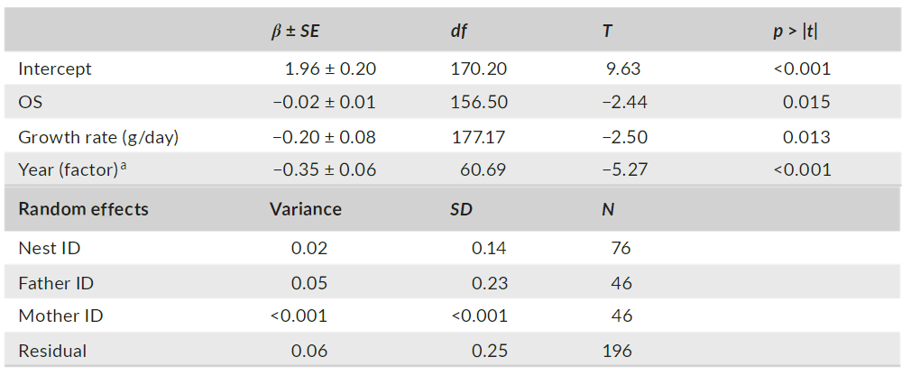

We can see some differences between the 2 of them. In mine some data are missing because I dodn’t know how to calculate it. The “Intercept” row has also really different values and I don’t know the reason of this huge difference. However, the “OS”, “Father ID” and “Residual” rows are very similar to the original table. “Growth rate” has a different coefficient but a similar t value. The “Mother ID” values are higher than the originals.